신록예찬's 블로그

# (노트) PyGSP

Jun 15, 2022 • 신록예찬 • 4 min read

기하학적 딥러닝

- ref
- install
- home
- Introduction to the PyGSP
- Introduction to spectral graph wavelets
- Optimization problems: graph TV vs. Tikhonov regularization
- Graph multiresolution: Kron pyramid

## ref

- https://pygsp.readthedocs.io/en/stable/tutorials/pyramid.html

## install

```
!pip install pygsp
```

## home

`-` The package includes a wide range of graphs,

from **point clouds** like

- the Stanford bunny
- and the Swiss roll;

to **networks like** the

- Minnesota road network;

to **models for generating random graphs** like

- stochastic block models,
- sensor networks,
- Erdős–Rényi model,
- Barabási-Albert model;

to **simple graphs** like the

- path,
- the ring,
- and the grid.

`-` Many filter banks are also provided, e.g.

**various wavelets** like

- the Mexican hat,
- Meyer, Half Cosine;

some **low-pass filters** like

- the heat kernel and
- the exponential window;

and **Gabor filters**.

`-` Despite all the pre-defined models, you can easily use a custom graph by defining its adjacency matrix, and a custom filter bank by defining a set of functions in the spectral domain.

`-` The following demonstrates how to instantiate a graph and a filter, the two main objects of the package.

```python
from pygsp import graphs, filters
import numpy as np
```

```python
!pip install pygsp
```

```python
G = graphs.Logo()
G.estimate_lmax()
g = filters.Heat(G, tau=10000)
```

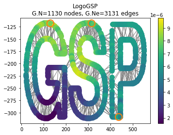

```python
DELTAS = [20,30,1090] # 신호가 시작되는 지점
s = np.zeros(G.N)
s[DELTAS] = 1
s=g.filter(s)
G.plot_signal(s,highlight=DELTAS, backend='matplotlib')
```

## Introduction to the PyGSP

```python
import numpy as np
import matplotlib.pyplot as plt
from pygsp import graphs, filters, plotting
```

```python
plotting.BACKEND = 'matplotlib'
plt.rcParams['figure.figsize'] = (10, 5)
```

```python
rs = np.random.RandomState(42)  # Reproducible results.
W = rs.uniform(size=(30, 30))  # Full graph.
W[W < 0.93] = 0  # Sparse graph.
W = W + W.T  # Symmetric graph.
np.fill_diagonal(W, 0)  # No self-loops.
G = graphs.Graph(W)
print('{} nodes, {} edges'.format(G.N, G.Ne))
```

```
30 nodes, 60 edges
```

```python
G.is_connected()
```

```
True
```

```python
G.is_directed()
```

```
False
```

```python
(G.W == W).all()
```

```
True
```

```python
type(G.W)
```

```
scipy.sparse._lil.lil_matrix
```

```python
G.L.shape
```

```
(30, 30)
```

```python
G.compute_fourier_basis()
```

```python
G.U.shape
```

```
(30, 30)
```

```python
G.D.shape
```

```
(60, 30)
```

```python
G.set_coordinates('ring2D')
```

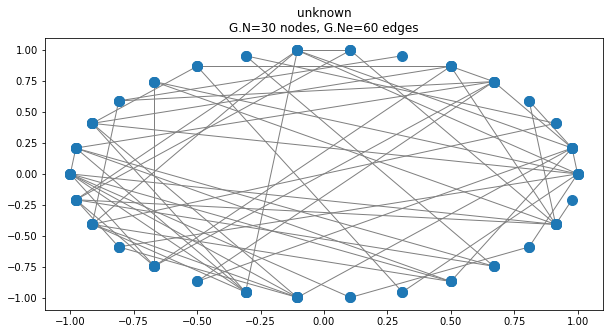

```python
G.plot()
```

```python
G = graphs.Logo()
```

```python
G.compute_fourier_basis()
```

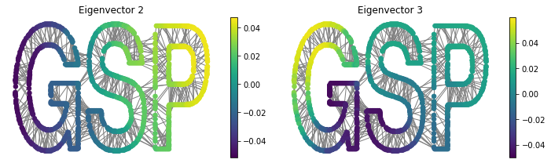

```python
fig, axes = plt.subplots(1, 2, figsize=(10, 3))
for i, ax in enumerate(axes):
    G.plot_signal(G.U[:, i+1], vertex_size=30, ax=ax)
    _ = ax.set_title('Eigenvector {}'.format(i+2))
    ax.set_axis_off()
fig.tight_layout()
```

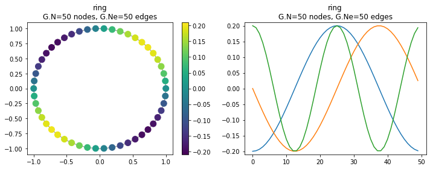

```python
G2 = graphs.Ring(N=50)
G2.compute_fourier_basis()
fig, axes = plt.subplots(1, 2, figsize=(10, 4))
G2.plot_signal(G2.U[:, 4], ax=axes[0])
G2.set_coordinates('line1D')
G2.plot_signal(G2.U[:, 1:4], ax=axes[1])
fig.tight_layout()
```

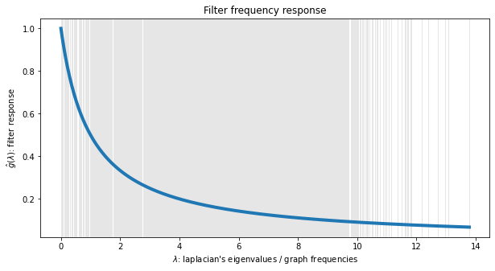

```python
tau = 1
def g(x):
    return 1. / (1. + tau * x)
g = filters.Filter(G, g)

fig, ax = plt.subplots()
g.plot(plot_eigenvalues=True, ax=ax)
_ = ax.set_title('Filter frequency response')
```

```python
s = np.zeros(G.N)
s[G.info['idx_g']-1] = -1
s[G.info['idx_s']-1] = 0
s[G.info['idx_p']-1] = 1
s += rs.uniform(-0.5, 0.5, size=G.N)
```

[figure not shown]

```python
s2 = g.filter(s)
fig, axes = plt.subplots(1, 2, figsize=(10, 3))
G.plot_signal(s, vertex_size=30, ax=axes[0])
_ = axes[0].set_title('Noisy signal')
axes[0].set_axis_off()
G.plot_signal(s2, vertex_size=30, ax=axes[1])
_ = axes[1].set_title('Cleaned signal')
axes[1].set_axis_off()
fig.tight_layout()
```

## Introduction to spectral graph wavelets

```python
import numpy as np
import matplotlib.pyplot as plt
from pygsp import graphs, filters, plotting, utils
```

```python
G = graphs.Bunny()
```

```python
taus = [10, 25, 50]
g = filters.Heat(G, taus)
```

```python
s = np.zeros(G.N)
DELTA = 20
s[DELTA] = 1
```

```python
s = g.filter(s, method='chebyshev')
```

[figure not shown]

```python
fig = plt.figure(figsize=(10, 3))
for i in range(g.Nf):
    ax = fig.add_subplot(1, g.Nf, i+1, projection='3d')
    G.plot_signal(s[:, i], colorbar=False, ax=ax)
    title = r'Heat diffusion, $\tau={}$'.format(taus[i])
    _ = ax.set_title(title)
    ax.set_axis_off()
fig.tight_layout()
```

```python
g = filters.MexicanHat(G, Nf=6)  # Nf = 6 filters in the filter bank.
```

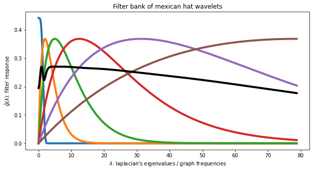

```python
fig, ax = plt.subplots(figsize=(10, 5))
g.plot(ax=ax)
_ = ax.set_title('Filter bank of mexican hat wavelets')
```

[figure not shown]

```python
s = g.localize(DELTA)
fig = plt.figure(figsize=(10, 2.5))
for i in range(3):
    ax = fig.add_subplot(1, 3, i+1, projection='3d')
    G.plot_signal(s[:, i], ax=ax)
    _ = ax.set_title('Wavelet {}'.format(i+1))
    ax.set_axis_off()
fig.tight_layout()
```

```python
s = G.coords
s = g.filter(s)
```

```python
s = np.linalg.norm(s, ord=2, axis=1)
```

[figure not shown]

```python
fig = plt.figure(figsize=(10, 7))
for i in range(4):
    ax = fig.add_subplot(2, 2, i+1, projection='3d')
    G.plot_signal(s[:, i], ax=ax)
    title = 'Curvature estimation (scale {})'.format(i+1)
    _ = ax.set_title(title)
    ax.set_axis_off()
fig.tight_layout()
```

## Optimization problems: graph TV vs. Tikhonov regularization

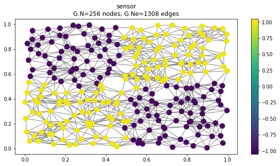

```python
import numpy as np
from pygsp import graphs, plotting
# Create a random sensor graph
G = graphs.Sensor(N=256, distribute=True, seed=42)
G.compute_fourier_basis()
# Create label signal
label_signal = np.copysign(np.ones(G.N), G.U[:, 3])
G.plot_signal(label_signal)
```

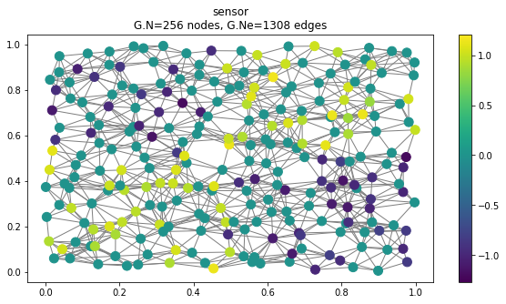

```python
rs = np.random.RandomState(42)
# Create the mask
M = rs.rand(G.N)
M = (M > 0.6).astype(float)  # Probability of having no label on a vertex.
# Applying the mask to the data
sigma = 0.1
subsampled_noisy_label_signal = M * (label_signal + sigma * rs.standard_normal(G.N))
G.plot_signal(subsampled_noisy_label_signal)
```

```
Solution found after 1000 iterations:
    objective function f(sol) = 2.024594e+02
    stopping criterion: MAXIT
```

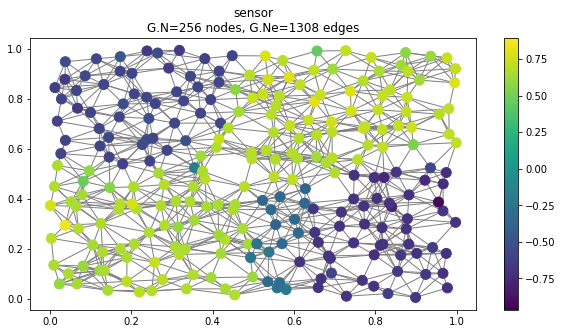

```python
# !pip install pyunlocbox
import pyunlocbox
# Set the functions in the problem
gamma = 3.0
d = pyunlocbox.functions.dummy()
r = pyunlocbox.functions.norm_l1()
f = pyunlocbox.functions.norm_l2(w=M, y=subsampled_noisy_label_signal,lambda_=gamma)
# Define the solver
G.compute_differential_operator()
L = G.D.toarray()
step = 0.999 / (1 + np.linalg.norm(L))
solver = pyunlocbox.solvers.mlfbf(L=L, step=step)

# Solve the problem
x0 = subsampled_noisy_label_signal.copy()
prob1 = pyunlocbox.solvers.solve([d, r, f], solver=solver, x0=x0, rtol=0, maxit=1000)
G.plot_signal(prob1['sol'])
```

```
Solution found after 1000 iterations:
    objective function f(sol) = 9.555135e+01
    stopping criterion: MAXIT
```

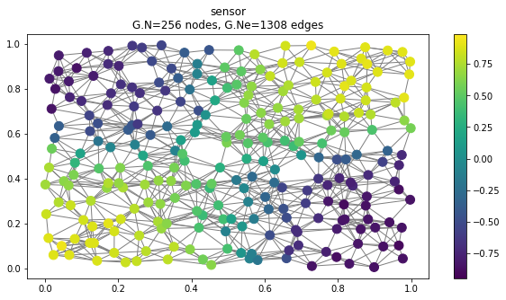

```python
r = pyunlocbox.functions.norm_l2(A=L, tight=False)
# Define the solver
step = 0.999 / np.linalg.norm(np.dot(L.T, L) + gamma * np.diag(M), 2)
solver = pyunlocbox.solvers.gradient_descent(step=step)
# Solve the problem
x0 = subsampled_noisy_label_signal.copy()
prob2 = pyunlocbox.solvers.solve([r, f], solver=solver,x0=x0, rtol=0, maxit=1000)
G.plot_signal(prob2['sol'])
```

## Graph multiresolution: Kron pyramid

```python
import numpy as np
from pygsp import graphs, reduction
```

```python
G = graphs.Sensor(512, distribute=True)
G.compute_fourier_basis()
```

```python
levels = 5
Gs = reduction.graph_multiresolution(G, levels, sparsify=False)
```

```python
for gr in Gs:
    gr.compute_fourier_basis()
```

```python
f = np.ones((G.N))
f[np.arange(G.N//2)] = -1
f = f + 10*Gs[0].U[:, 7]
```

```python
f2 = np.ones((G.N, 2))
f2[np.arange(G.N//2)] = -1
```

```python
g = [lambda x: 5./(5 + x)]
```

```python
ca, pe = reduction.pyramid_analysis(Gs, f, h_filters=g, method='exact')
ca2, pe2 = reduction.pyramid_analysis(Gs, f2, h_filters=g, method='exact')
```

```python
f_pred, _ = reduction.pyramid_synthesis(Gs, ca[levels], pe, method='exact')
f_pred2, _ = reduction.pyramid_synthesis(Gs, ca2[levels], pe2, method='exact')
```

```python
err = np.linalg.norm(f_pred-f)/np.linalg.norm(f)
err2 = np.linalg.norm(f_pred2-f2)/np.linalg.norm(f2)
assert (err < 1e-10) & (err2 < 1e-10)
```